# Exercise 3

Fortgeschrittene Statistische Software für NF

Jonathan Johnsen(12568800)

2024-06-06

## General Remarks

- You can submit your solutions in teams of up to 3 students.
- Include all your team-member’s names and student numbers (Martrikelnummern) in the `authors` field.
- Please use the exercise template document to work on and submit your results.
- Use a level 2 heading for each new exercise and answer each subtask next to it’s bullet point or use a new level 3 heading if you want.
- Always render the R code for your solutions and make sure to include the resulting data in your rendered document.
  - Make sure to not print more than 10 rows of data (unless specifically instructed to).
- Always submit both the rendered document(s) as well as your source Rmarkdown document. Submit the files separately on moodle, **not** as a zip archive.

## Exercise 1: Initializing git (4 Points)

For this whole exercise sheet we will be tracking all our changes to it in git.

### a)

```r
#a)  Start by initializing a new R project with git support, called
#    `2024-exeRcise-sheet-3`. If you forgot how to do this, you can
#    follow this
#    [guide](https://malikaihle.github.io/Introduction-RStudio-Git-GitHub/rstudio_project.html).
```

### b)

```r
#b)  Commit the files generated by Rstudio.
```

### c)

```r
#c)  For all of the following tasks in this exercise sheet we ask you to
#    always commit your changes after finishing each subtask e.g. create
#    a commit after task *1d*, *1e* etc.
```

```
#> Note: This applies only to answers that have text or code as their
#> answer. If you complete tasks in a different order or forget to commit
#> one, this is no problem. If you change your answers you can just
#> create multiple commits to track the changes.
```

### d)

```r
#d)  Name 2 strengths and 2 weaknesses of git. (Don't forget to create a
#    commit after this answer, see *1c*)
```

Strengths :

1. You always have backups from older versions in case something went very wrong with one of your updates
2. It makes it much easier to work in groups with other people as everyone can just work on their own features and than commit them

Weaknesses:

1. It has a steep learning curve for beginners
2. If you have a really big project it might take up a a ton of storage to safe all the changes and older versions

```r
#e)  Knit this exercise sheet. Some new files will automatically be
#    generated when knitting the sheet e.g. the HTML page. Ignore these
#    files, as we only want to track the source files themselves.
```

## Exercise 2: Putting your Repository on GitHub (3.5 Points)

For this task you will upload your solution to GitHub.

### a)

```r
#a)  Create a new repository on GitHub in your account named
#    `exeRcise-sheet-3`. Make sure you create a **public repository** so
#    we are able to see it for grading. Add the link to the repository
#    below:
```

You can find my GitHub repo here : https://github.com/JonathanJohnsenLMU/exeRcise-sheet-3

### b)

```r
#b)  Push your code to this new repository by copying and executing the
#    snippet on github listed under
#    `…or push an existing repository from the command line`.

#The first few commits are from my private GitHub account because I forgot to witch to the one I created for this
```

### c)

```r
#c)  Regularly push your latest changes to GitHub again and especially do
#    so when you are finished with this sheet.
```

## Exercise 3: Baby-Names in Munich (3.5 Points)

Download the latest open datasets on given names (“Vornamen”) from the open data repository of the city of Munich for the years `2023` and `2022`.

Link: https://opendata.muenchen.de/dataset/vornamen-von-neugeborenen

### a)

```r
#a)  Download the data for both years and track it in git. For small
#    datasets like these adding them to git is not a problem.
```

### b)

```r
#b)  Load the data for both years into R. Check the type of the count
#    variable ("Anzahl") and look into the data to determine why it is
#    not numeric? Fix the problem in an appropriate manner, it is OK if
#    some of the counts are inaccurate because of this. Explain your
#    solution and the repercussions.

name_data_2023 <- read_csv("data//vornamen-muenchen-2023.csv")
name_data_2022 <- read_csv("data//open_data_portal_2022.csv")

#class(name_data$Anzahl) used to check the inital type
#It would appear that "Anzahl"s data type is "character"

#This is because some of the rows are not just made up of numbers for instance the name "Aadhvika" contains the information "4 oder weniger"(4 or less) in 2023

#I will fix this by just having it ignore all the text and using the given maximum number I am assuming that's probably what you meant by "it is OK if some of the counts are inaccurate"
name_data_2023 <- name_data_2023 %>% mutate(Anzahl = parse_number(Anzahl))
name_data_2022 <- name_data_2022 %>% mutate(Anzahl = parse_number(Anzahl))

#class(name_data$Anzahl) used to check that it did in fact change to numerical
```

### c)

```r
#c)  Calculate the total number of babies born in Munich in 2022
#    and 2023. Which year had the bigger baby-boom?
total_babys_2022 <- name_data_2022 %>% summarise(sum = sum(Anzahl,na.rm=TRUE))
total_babys_2023 <- name_data_2023 %>% summarise(sum = sum(Anzahl,na.rm=TRUE))
```

**25199** Babys were born in 2022 and **24229** in 2023, so 2022 had more

### d)

```r
#d)  Add a new column `year` to both datasets which holds the correct
#    year for each.

name_data_2022 <- name_data_2022 %>% mutate(year=2022)
name_data_2023 <- name_data_2023 %>% mutate(year=2023)
```

### e)

```r
#e)  Combine both datasets into one using `bind_rows()`.
name_data <- bind_rows(name_data_2022,name_data_2023)
```

### f)

```r
#f)  Combine the counts for same names to determine the most popular
#    names across both years. Print out the top 10 names in a nicely
#    formatted table for both years. Include a table caption.

most_picked_names <- name_data %>% group_by(Vorname) %>% summarize(total_times_picked = sum(Anzahl,na.rm=TRUE))
most_picked_names <- most_picked_names %>% arrange(desc(total_times_picked))

top_10_names <- most_picked_names %>% slice(1:10)
knitr::kable(top_10_names)
```

| Vorname | total_times_picked |
| --- | --- |
| Maximilian | 209 |
| Emilia | 192 |
| Leon | 188 |
| Anton | 181 |
| Emma | 172 |
| Felix | 166 |
| Mia | 163 |
| Paul | 161 |
| Noah | 159 |
| Jonas | 158 |

## Exercise 4: Open Analysis (4 points)

This exercise is a bit more open-ended. You can choose any dataset from [Our World in Data](https://ourworldindata.org/) and analyze it, while determining the research question yourself.

### a)

```r
#a)  Go to <https://github.com/owid/owid-datasets/tree/master/datasets>
#    and choose a dataset that interests you. You can have a look at
#    <https://ourworldindata.org/> to gather some inspiration.
```

### b)

```r
#b)  Download the dataset and track it in git.
```

### c)

```r
#c)  Put the name / title of the dataset and a link to it below.
```

- Dataset Name: Child mortality by income level (1960-2012) - World Bank (WDI) (2016)
- Link: https://github.com/owid/owid-datasets/blob/master/datasets/Child%20mortality%20by%20income%20level%20(1960-2012)%20-%20World%20Bank%20(WDI)%20(2016)/Child%20mortality%20by%20income%20level%20(1960-2012)%20-%20World%20Bank%20(WDI)%20(2016).csv

### d)

```r
#d)  Come up with a (research) question you want to answer with the data
#    and briefly explain why you believe this is an interesting question
#    within one sentence. It should be a question that can be answered
#    with the dataset and using R.
```

I want to figure out if rich people have disproportionately benefited from advancements in medicine that pertain to child care.

I think this is an interesting question because I think that it would be unfair to poor children if there clearly are ways to help them but they cannot access them because of their financial situation

### e)

```r
#e)  Use R to answer your chosen question.
mortality_data <- read_csv("data//Child mortality by income level (1960-2012) - World Bank (WDI) (2016).csv")

#Step 1 group all the data by the income bracket(Entity)
#Step 2 Sort it by Year#
#Step 3 calulate by how much percent the mortality rate changed every year
mortality_data <- mortality_data  %>% group_by(Entity) %>% arrange(Year) %>% mutate(percentage_change = `Child mortality by income level (1960-2012) (World Bank (WDI) (2016))` / lag(`Child mortality by income level (1960-2012) (World Bank (WDI) (2016))`))

#step 4 calculate how much percent mortality rate changed on average every year
average_change_rates <- mortality_data %>% summarise(avg_change = mean(percentage_change,na.rm=TRUE))

#step 5 Sort it by the average change so we can easily see who has had the biggest improvement
average_change_rates <- average_change_rates %>% arrange(avg_change)
#head(average_change_rates)
```

Yes Low income people benefit the least, however Upper middle income people have in terms of percentages benefited the most

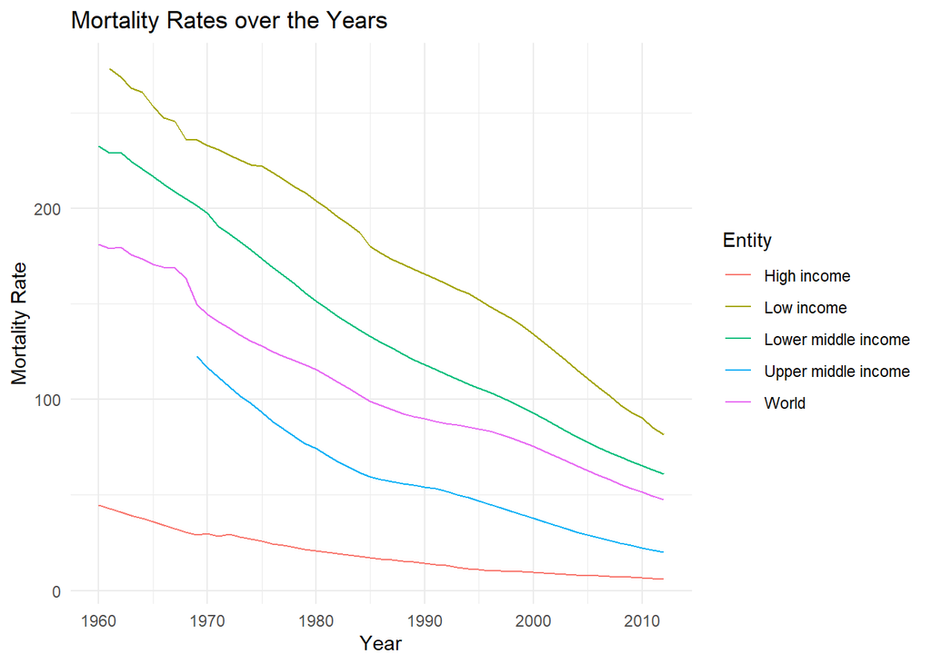

Mortality Rates

```r
#f)  Create a meaningful plot / figure with the dataset. Make sure to
#    provide a figure caption (via the chunk options / Rmarkdown) and
#    correctly label the figure.

ggplot(mortality_data, aes(x = Year, y = `Child mortality by income level (1960-2012) (World Bank (WDI) (2016))`, color = Entity, group = Entity)) +
  geom_line() +
  labs(title = "Mortality Rates over the Years",
       x = "Year",
       y = "Mortality Rate") +
  theme_minimal()
```

## Final Note

Make sure to push all your commits and changes to GitHub before submittining the exercise sheet.